# Applications of PostGIS Functions

In this notebook, we will look at OSM and GADM data and perform PostGIS function to perform basic exploratory analysis

```python
import psycopg2
import numpy as np
import pandas as pd
import matplotlib.pyplot as plt
import geopandas as gpd
```

We first establish a connection to our database

```python
conn = psycopg2.connect(dbname="postgis",
                 user="gsa2022",
                 password="g5!V%T1Vmd",
                 host="192.168.212.99",
                 port=32771)
```

## Assignment

Suppose that you are the *head of branch expansion* of food chain "McDollibee" with the base of operations located here at AIM. You are tasked to create a strategy that considers the following:

1. Level of Urbanization - You want to expand to a location where the amenity density is in top 10 percentile.
2. Market Availability and Competition - You cater to students but you prefer areas with limited competition
3. Logistics - The farther the location is from AIM, the more expensive building the branch will be.

Using the information available to you, create a report on what possible locations fit the requirements of your branch expansion strategy.

```python
#Your Code and Report Here
df_urban = pd.read_sql("""
select
    name_2, count(amenity)
from
    gadm.ph as g
join
    public.ph_point AS p ON st_within(st_transform(p.way, 3123), st_transform(g.geom, 3123))
where
    g.name_1 = 'Metropolitan Manila' and p.amenity is not null
group by
    1
order by
    2 desc
""", conn)
df_urban
```

|  | name_2 | count |
| --- | --- | --- |
| 0 | Quezon City | 3836 |
| 1 | Makati City | 2333 |
| 2 | Manila | 1863 |
| 3 | Pasig City | 1078 |
| 4 | Parañaque | 844 |
| 5 | Marikina | 736 |
| 6 | Pasay City | 711 |
| 7 | Muntinlupa | 666 |
| 8 | Las Piñas | 614 |
| 9 | Mandaluyong | 492 |
| 10 | Kalookan City | 473 |
| 11 | San Juan | 406 |
| 12 | Valenzuela | 320 |
| 13 | Taguig | 220 |
| 14 | Malabon | 190 |
| 15 | Pateros | 75 |
| 16 | Navotas | 57 |

### Level of Urbanization

We focused on cities within the metropolitan manila area and saw that the most urbanized cities that belong to the 90th percentile were `Quezon City` and `Makati City`. These two cities are our best options where we can put up the new branch. However, since due to logistics constraints, it will be more costly for us to establish the branch in `Quezon City` compared to establishing it in `Makati City` where AIM is located.

```python
df_urban[df_urban['count']>= df_urban['count'].quantile(0.9)]
```

|  | name_2 | count |
| --- | --- | --- |
| 0 | Quezon City | 3836 |
| 1 | Makati City | 2333 |

## Market Research

```python
df_schools_avoid = gpd.read_postgis('''
select
    p1.name, st_transform(p1.way,3123) as geom
from
    public.ph_point as p1
join
    public.ph_point as p2 on ST_dwithin(st_transform(p1.way,3123),st_transform(p2.way,3123),400)
join
    gadm.ph as g on st_within(st_transform(p1.way,3123),st_transform(g.geom,3123))
where
    p1.amenity = 'school' and g.name_2 = 'Makati City' and p2.amenity = 'fast_food'
''',con = conn, geom_col = 'geom')
df_schools_avoid
```

|  | name | geom |
| --- | --- | --- |
| 0 | Bangkal Elementary School | POINT (501043.141 1608638.116) |
| 1 | Bangkal Elementary School (Main) | POINT (501109.599 1608806.079) |
| 2 | Bangkal High School (Main) | POINT (501191.795 1608797.252) |
| 3 | Bangkal Elementary School | POINT (501043.141 1608638.116) |
| 4 | Bangkal Elementary School (Main) | POINT (501109.599 1608806.079) |
| ... | ... | ... |
| 269 | School of Mind Achivers and Reseachers of Tomo... | POINT (506621.194 1608916.275) |
| 270 | School of Mind Achivers and Reseachers of Tomo... | POINT (506621.194 1608916.275) |
| 271 | School of Mind Achivers and Reseachers of Tomo... | POINT (506621.194 1608916.275) |
| 272 | School of Mind Achivers and Reseachers of Tomo... | POINT (506621.194 1608916.275) |
| 273 | None | POINT (505874.251 1610698.333) |

274 rows × 2 columns

These are the schools in makati that have at least 1 fast food amenity within a walking distance of 400 meters near them. We have a total of `32` schools.

```python
print('Total of',df_schools_avoid.drop_duplicates(['name']).shape[0]-1, 'schools')
df_schools_avoid.drop_duplicates(['name'])
```

```
Total of 32 schools
```

|  | name | geom |
| --- | --- | --- |
| 0 | Bangkal Elementary School | POINT (501043.141 1608638.116) |
| 1 | Bangkal Elementary School (Main) | POINT (501109.599 1608806.079) |
| 2 | Bangkal High School (Main) | POINT (501191.795 1608797.252) |
| 10 | Rizal City School | POINT (500713.255 1609012.218) |
| 12 | Bangkal Computer Center | POINT (500864.865 1608904.622) |
| 14 | AMA School of Medicine-Makati | POINT (501208.410 1608914.143) |
| 15 | AMA School of Medicine | POINT (501211.180 1608912.495) |
| 16 | AMACC Makati | POINT (501166.992 1608996.691) |
| 17 | Teacher Marie | POINT (500851.378 1609315.217) |
| 33 | Microcadd Institute Makati | POINT (501444.948 1609609.566) |
| 34 | New Simulator Center of the Phils. | POINT (500227.681 1609594.118) |
| 38 | San Isidro National High School (Annex) | POINT (501157.283 1609886.367) |
| 50 | Informatics | POINT (501852.630 1610145.589) |
| 55 | San Antonio National High School | POINT (500537.530 1610423.881) |
| 58 | The Bridge | POINT (501244.313 1610300.062) |
| 76 | Greenhouse Training and Assesment Center Inc. | POINT (500159.645 1610684.707) |
| 80 | First Gear Technical Institute and Assesment C... | POINT (501379.057 1611338.864) |
| 81 | EWPCI Training & Testing Center | POINT (501347.192 1611366.966) |
| 82 | Inquirer Academy | POINT (501402.655 1611364.655) |
| 106 | iAcademy | POINT (501959.849 1610438.271) |
| 114 | Spurgeon School Foundation | POINT (502089.533 1610397.264) |
| 142 | Playworks School | POINT (502379.598 1610373.131) |
| 163 | NATIONAL MARITIME POLYTECHNIC Makati (NMP) | POINT (502702.074 1610532.379) |
| 193 | Jose Magsaysay Elementary School | POINT (502197.380 1611712.979) |
| 194 | Integrated Montessori Center | POINT (504204.431 1606320.845) |
| 195 | Kelly Academy International | POINT (504633.866 1609542.452) |
| 197 | Little Gym | POINT (504592.400 1609724.049) |
| 256 | Maranatha Christian School | POINT (504876.967 1610508.987) |
| 257 | San Carlos Seminary, Guadalupe, Makati City | POINT (504583.683 1610965.947) |
| 265 | Apple Seed Montissori | POINT (504978.053 1608560.163) |
| 266 | ICBB | POINT (504970.652 1608601.662) |
| 268 | School of Mind Achivers and Reseachers of Tomo... | POINT (506621.194 1608916.275) |
| 273 | None | POINT (505874.251 1610698.333) |

However, if we query all of the schools in Makati, there are a total of `37` schools. This means that only `5` schools do not have a fast food amenity within a 400 meter radius around them.

```python
df_all_schools = gpd.read_postgis('''
select
    p1.name, st_transform(p1.way,3123) as geom
from
    public.ph_point as p1
join
    gadm.ph as g on st_within(st_transform(p1.way,3123),st_transform(g.geom,3123))
where
    p1.amenity = 'school' and g.name_2 = 'Makati City'
''',con = conn, geom_col = 'geom')
df_all_schools
```

|  | name | geom |
| --- | --- | --- |
| 0 | Bangkal Elementary School | POINT (501043.141 1608638.116) |
| 1 | Philippines School of Interior Design | POINT (501603.019 1608599.863) |
| 2 | Greenhouse Training and Assesment Center Inc. | POINT (500159.645 1610684.707) |
| 3 | Rizal City School | POINT (500713.255 1609012.218) |
| 4 | Bangkal Elementary School (Main) | POINT (501109.599 1608806.079) |
| 5 | Bangkal Computer Center | POINT (500864.865 1608904.622) |
| 6 | Bangkal High School (Main) | POINT (501191.795 1608797.252) |
| 7 | AMA School of Medicine-Makati | POINT (501208.410 1608914.143) |
| 8 | AMA School of Medicine | POINT (501211.180 1608912.495) |
| 9 | AMACC Makati | POINT (501166.992 1608996.691) |
| 10 | Teacher Marie | POINT (500851.378 1609315.217) |
| 11 | New Simulator Center of the Phils. | POINT (500227.681 1609594.118) |
| 12 | San Isidro National High School (Annex) | POINT (501157.283 1609886.367) |
| 13 | Microcadd Institute Makati | POINT (501444.948 1609609.566) |
| 14 | San Antonio National High School | POINT (500537.530 1610423.881) |
| 15 | The Bridge | POINT (501244.313 1610300.062) |
| 16 | Informatics | POINT (501852.630 1610145.589) |
| 17 | iAcademy | POINT (501959.849 1610438.271) |
| 18 | Spurgeon School Foundation | POINT (502089.533 1610397.264) |
| 19 | Playworks School | POINT (502379.598 1610373.131) |
| 20 | First Gear Technical Institute and Assesment C... | POINT (501379.057 1611338.864) |
| 21 | EWPCI Training & Testing Center | POINT (501347.192 1611366.966) |
| 22 | Inquirer Academy | POINT (501402.655 1611364.655) |
| 23 | Jose Magsaysay Elementary School | POINT (502197.380 1611712.979) |
| 24 | Integrated Montessori Center | POINT (504204.431 1606320.845) |
| 25 | Integrated Montessori Center | POINT (504374.811 1606872.387) |
| 26 | Apple Seed Montissori | POINT (504978.053 1608560.163) |
| 27 | ICBB | POINT (504970.652 1608601.662) |
| 28 | Kelly Academy International | POINT (504633.866 1609542.452) |
| 29 | Little Gym | POINT (504592.400 1609724.049) |
| 30 | NATIONAL MARITIME POLYTECHNIC Makati (NMP) | POINT (502702.074 1610532.379) |
| 31 | Guadalupe Central Elementary School | POINT (504262.657 1610099.476) |
| 32 | Full Bright Science School | POINT (504550.908 1610271.588) |
| 33 | Pineslight School | POINT (504864.662 1610378.685) |
| 34 | Maranatha Christian School | POINT (504876.967 1610508.987) |
| 35 | San Carlos Seminary, Guadalupe, Makati City | POINT (504583.683 1610965.947) |
| 36 | School of Mind Achivers and Reseachers of Tomo... | POINT (506621.194 1608916.275) |
| 37 | South Cembo Elementary School | POINT (505228.714 1610217.283) |
| 38 | None | POINT (505874.251 1610698.333) |

```python
all_unique_schools = df_all_schools.drop_duplicates(['name'])
all_unique_schools.shape[0]-1
```

```
37
```

These are the 5 schools that do not have any fast food amenity within walking distance of their location. These are the schools that the company should try to target.

```python
df_potential = all_unique_schools[~all_unique_schools['name'].isin(df_schools_avoid.drop_duplicates(['name'])['name'])]
df_potential
```

|  | name | geom |
| --- | --- | --- |
| 1 | Philippines School of Interior Design | POINT (501603.019 1608599.863) |
| 31 | Guadalupe Central Elementary School | POINT (504262.657 1610099.476) |
| 32 | Full Bright Science School | POINT (504550.908 1610271.588) |
| 33 | Pineslight School | POINT (504864.662 1610378.685) |
| 37 | South Cembo Elementary School | POINT (505228.714 1610217.283) |

All the fast food amenities in makati city for plotting.

```python
df_fastfood = gpd.read_postgis('''
select
    p1.name, st_transform(p1.way,3123) as geom
from
    public.ph_point as p1
join
    gadm.ph as g on st_within(st_transform(p1.way,3123),st_transform(g.geom,3123))
where
    p1.amenity = 'fast_food' and g.name_2 = 'Makati City'
''',con = conn, geom_col = 'geom')
df_fastfood
```

|  | name | geom |
| --- | --- | --- |
| 0 | Jollibee | POINT (501160.885 1607990.212) |
| 1 | Pizza Hut Evangelista | POINT (501165.712 1608021.114) |
| 2 | McDonald's | POINT (501189.035 1607996.011) |
| 3 | Mang Inasal | POINT (501192.041 1608019.699) |
| 4 | Kowloon House | POINT (501171.239 1608103.176) |
| ... | ... | ... |
| 241 | Jala | POINT (505723.328 1610769.199) |
| 242 | Joshua's Siomai etc | POINT (506235.711 1610292.797) |
| 243 | Angel's Burger | POINT (506631.313 1610269.900) |
| 244 | Fariñas Ilocano Empanada | POINT (502783.487 1611261.271) |
| 245 | Burger Machine | POINT (505145.172 1611164.069) |

246 rows × 2 columns

### Recommendation

Integrating all the information that we have gathered, we can now plot the schools, the targets, AIM, and all the fast food amenities in a plot. As we can see from the plot below, the upper right quadrant clearly is the best location to set up the branch for Mcdollibee. This quadrant contains 4 out of 5 target schools and it is less dense in terms of competition. While there are less competitors in this quadrant, it can also be observed that the market there is also fewer than that of the upper left quadrant where most of the market and competition are concentrated. However, it is still profitable to establish a branch in the upper right quadrant since we can capitalize on the 4 schools that do not have a fast food amenity within walking distance. It is recommended that we establish the branch in this quadrant, specifically on the location where we can tap the 4 target schools.

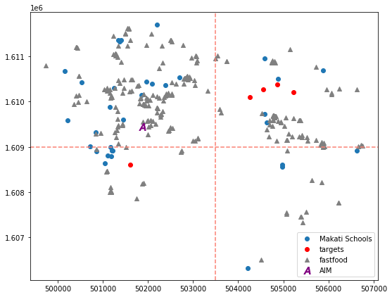

```python
fig, ax = plt.subplots(figsize=(25,7))

df_schools_avoid.drop_duplicates(['name']).plot(ax=ax, label='Makati Schools')

AIM = gpd.read_postgis('''
SELECT ST_TRANSFORM(ST_SETSRID(ST_POINT(121.0187, 14.5524), 4326), 3123) as aim_loc'''
, con=conn, geom_col='aim_loc')



df_potential.plot(ax=ax, color='red', label='targets')
df_fastfood.plot(ax=ax, color='grey', label='fastfood', marker='^')
AIM.plot(color='purple', ax=ax, label='AIM', marker='$A$', markersize=100)
plt.axvline(503500, ls='--', color='salmon')
plt.axhline(y=1609000, ls='--', color='salmon')
plt.legend(loc=4)
plt.show()
```